# Project in Mathematical Modelling

## Currency Denomination Recognition using Banknote-Net Dataset

## 23200555

### Importing Libraries

```python
import numpy as np
import pandas as pd
import matplotlib.pyplot as plt
import seaborn as sns
import time

from sklearn.manifold import TSNE
from sklearn.model_selection import train_test_split, StratifiedKFold
from sklearn.metrics import classification_report, confusion_matrix

import tensorflow as tf
from tensorflow.keras.models import Sequential, load_model, Model
from tensorflow.keras.layers import Dense, Dropout, Input
from tensorflow.keras.optimizers import Adam
from tensorflow.keras.callbacks import ModelCheckpoint, EarlyStopping
from tensorflow.keras.metrics import Precision, Recall

# Set random seed for reproducibility
np.random.seed(23200555)
tf.random.set_seed(23200555)
```

We'll be loading our dataset using a `.feather` format file instead of a `.csv` due to its fast read/write capabilities.

```python
# Load data from either .csv or .feather
currency_data = pd.read_feather("data/banknote_net.feather") # feather is faster and more robust than csv.
currency_data.head()
```

|  | v_0 | v_1 | v_2 | v_3 | v_4 | v_5 | v_6 | v_7 | v_8 | v_9 | ... | v_248 | v_249 | v_250 | v_251 | v_252 | v_253 | v_254 | v_255 | Currency | Denomination |
| --- | --- | --- | --- | --- | --- | --- | --- | --- | --- | --- | --- | --- | --- | --- | --- | --- | --- | --- | --- | --- | --- |
| 0 | 0.423395 | 0.327657 | 2.568988 | 3.166228 | 4.801421 | 5.531792 | 2.458083 | 1.218453 | 0.000000 | 1.116785 | ... | 0.000000 | 2.273451 | 5.790633 | 0.000000 | 0.000000 | 0.0 | 5.635400 | 0.000000 | AUD | 100_1 |
| 1 | 1.158823 | 1.669602 | 3.638447 | 2.823524 | 4.839890 | 2.777757 | 0.753350 | 0.764005 | 0.347871 | 1.928572 | ... | 0.000000 | 2.329623 | 3.516146 | 0.000000 | 0.000000 | 0.0 | 2.548191 | 1.053410 | AUD | 100_1 |
| 2 | 0.000000 | 0.958235 | 4.706119 | 1.688242 | 3.312702 | 4.516483 | 0.000000 | 1.876461 | 2.250795 | 1.883192 | ... | 0.811282 | 5.591417 | 1.879267 | 0.641139 | 0.571079 | 0.0 | 1.861483 | 2.172145 | AUD | 100_1 |
| 3 | 0.920511 | 1.820294 | 3.939334 | 3.206829 | 6.253655 | 0.942557 | 2.952453 | 0.000000 | 2.064298 | 1.367196 | ... | 1.764936 | 3.415151 | 2.518404 | 0.582229 | 1.105192 | 0.0 | 1.566918 | 0.533945 | AUD | 100_1 |
| 4 | 0.331918 | 0.000000 | 3.330771 | 3.023437 | 4.369099 | 5.177336 | 1.499362 | 0.590646 | 0.553625 | 1.405708 | ... | 0.000000 | 4.615945 | 4.825463 | 0.302261 | 0.378229 | 0.0 | 2.710654 | 0.325945 | AUD | 100_1 |

5 rows × 258 columns

The first 256 columns correspond to image embeddings and the last two columns contain the associated currency and denomination of the note.

```python
# Total number of images
print(f"Total number of images is {currency_data.shape[0]}")

# Unique number of currencies
print(f"Total number of currencies is {currency_data.Currency.unique().shape[0]}")

# Unique number of denominations (including back and front of each banknote)
combined_series = currency_data.Currency + currency_data.Denomination # combination of currency and denomination
print(f"Total number of denominations is {int(len(combined_series.unique()) / 2)}")

# Inspect data structure
currency_data.head(10)
```

```
Total number of images is 24826
Total number of currencies is 17
Total number of denominations is 112
```

|  | v_0 | v_1 | v_2 | v_3 | v_4 | v_5 | v_6 | v_7 | v_8 | v_9 | ... | v_248 | v_249 | v_250 | v_251 | v_252 | v_253 | v_254 | v_255 | Currency | Denomination |
| --- | --- | --- | --- | --- | --- | --- | --- | --- | --- | --- | --- | --- | --- | --- | --- | --- | --- | --- | --- | --- | --- |
| 0 | 0.423395 | 0.327657 | 2.568988 | 3.166228 | 4.801421 | 5.531792 | 2.458083 | 1.218453 | 0.000000 | 1.116785 | ... | 0.000000 | 2.273451 | 5.790633 | 0.000000 | 0.000000 | 0.000000 | 5.635400 | 0.000000 | AUD | 100_1 |
| 1 | 1.158823 | 1.669602 | 3.638447 | 2.823524 | 4.839890 | 2.777757 | 0.753350 | 0.764005 | 0.347871 | 1.928572 | ... | 0.000000 | 2.329623 | 3.516146 | 0.000000 | 0.000000 | 0.000000 | 2.548191 | 1.053410 | AUD | 100_1 |
| 2 | 0.000000 | 0.958235 | 4.706119 | 1.688242 | 3.312702 | 4.516483 | 0.000000 | 1.876461 | 2.250795 | 1.883192 | ... | 0.811282 | 5.591417 | 1.879267 | 0.641139 | 0.571079 | 0.000000 | 1.861483 | 2.172145 | AUD | 100_1 |
| 3 | 0.920511 | 1.820294 | 3.939334 | 3.206829 | 6.253655 | 0.942557 | 2.952453 | 0.000000 | 2.064298 | 1.367196 | ... | 1.764936 | 3.415151 | 2.518404 | 0.582229 | 1.105192 | 0.000000 | 1.566918 | 0.533945 | AUD | 100_1 |
| 4 | 0.331918 | 0.000000 | 3.330771 | 3.023437 | 4.369099 | 5.177336 | 1.499362 | 0.590646 | 0.553625 | 1.405708 | ... | 0.000000 | 4.615945 | 4.825463 | 0.302261 | 0.378229 | 0.000000 | 2.710654 | 0.325945 | AUD | 100_1 |
| 5 | 0.000000 | 0.579322 | 3.951283 | 2.789169 | 4.397989 | 5.207006 | 1.094531 | 0.967335 | 1.249324 | 1.639024 | ... | 0.159039 | 4.868283 | 4.599572 | 0.941216 | 0.704969 | 0.000000 | 2.232955 | 1.204827 | AUD | 100_1 |
| 6 | 0.000000 | 0.267766 | 3.068679 | 1.999993 | 4.180965 | 4.987628 | 1.141044 | 0.675234 | 0.454930 | 1.218580 | ... | 0.000000 | 4.023349 | 3.999944 | 0.754004 | 0.383292 | 0.000000 | 2.701403 | 1.770314 | AUD | 100_1 |
| 7 | 0.000000 | 0.884940 | 4.487358 | 3.647301 | 2.086322 | 4.824439 | 0.184787 | 1.605425 | 1.769273 | 1.486702 | ... | 0.721975 | 6.629235 | 3.773829 | 0.000000 | 1.486893 | 0.511956 | 2.496674 | 0.337508 | AUD | 100_1 |
| 8 | 0.000000 | 0.638652 | 6.130018 | 3.259331 | 2.874515 | 4.259819 | 0.948092 | 0.948465 | 1.303086 | 1.145841 | ... | 1.677202 | 5.358987 | 3.290113 | 0.000000 | 0.354480 | 0.000000 | 2.524134 | 0.792196 | AUD | 100_1 |
| 9 | 0.000000 | 0.744923 | 3.864101 | 0.600698 | 2.609252 | 4.821238 | 1.397394 | 0.000000 | 1.283926 | 1.121008 | ... | 0.531523 | 3.229470 | 3.241802 | 0.000000 | 1.377622 | 0.000000 | 1.475371 | 0.828369 | AUD | 100_1 |

10 rows × 258 columns

Furthermore, The Denomination column also gives information about whether the image is of note's frontface or rearface i.e. **100_1** corresponds to a frontface image whereas **100_2** corresponds to a rear image.

### Exploratory Data Analysis

```python
currency_data.Currency.value_counts()
```

| Currency | count |
| --- | --- |
| TRY | 2888 |
| BRL | 2078 |
| INR | 1921 |
| EUR | 1905 |
| JPY | 1658 |
| AUD | 1616 |
| USD | 1604 |
| MYR | 1202 |
| IDR | 1164 |
| PHP | 1164 |
| CAD | 1162 |
| NZD | 1156 |
| PKR | 1131 |
| MXN | 1122 |
| GBP | 1108 |
| SGD | 1015 |
| NNR | 932 |

**dtype:** int64

```python
# Extract image feature embeddings
features = currency_data.drop(['Currency', 'Denomination'], axis=1)

# Save currency labels for later use in plotting
labels = currency_data['Currency']
```

#### T-SNE

```python
start=time.time()

# t-SNE transformation
tsne = TSNE(n_components=2, perplexity=25, n_iter=1000, verbose=1)
tsne_results = tsne.fit_transform(features)

end=time.time()
print("Time taken to execute",end-start)
```

[output not shown]

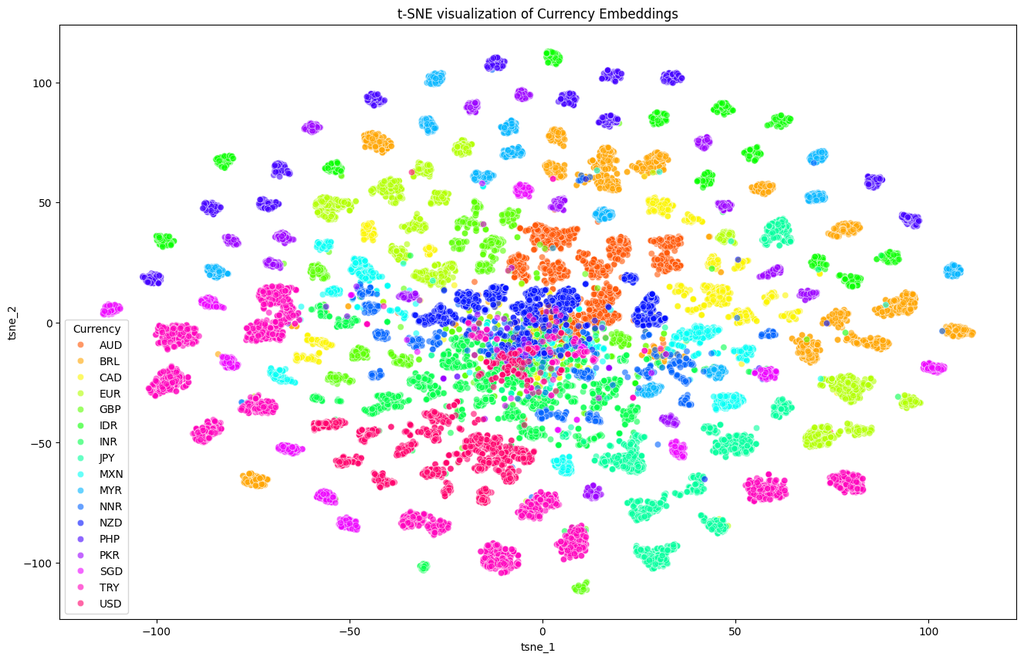

```python
# Create a DataFrame containing the 2D coordinates of t-SNE embeddings
tsne_df = pd.DataFrame({
    'tsne_1': tsne_results[:, 0],
    'tsne_2': tsne_results[:, 1],
    'Currency': labels
})

# Plotting
plt.figure(figsize=(16, 10))
sns.scatterplot(
    x='tsne_1', y='tsne_2',
    hue='Currency',
    palette=sns.color_palette("hsv", len(tsne_df['Currency'].unique())),
    data=tsne_df,
    legend="full",
    alpha=0.6
)
plt.title('t-SNE visualization of Currency Embeddings')
plt.show()
```

- **From the above t-SNE visualization:** The plot vividly illustrates the distinctive clusters formed by different currencies within the dataset, with each cluster color corresponding to a specific currency.
- **Clear Segregation of Currencies:** This clustering effect underscores the dataset's well-defined segregation of currencies, highlighting the variations within each currency in terms of denominations.
- **Representation of Denominations:** Each visible grouping represents a different denomination of a currency, either the front or back of the banknote, showcasing the model's ability to capture and separate intricate features inherent to each currency type.

### Data Preprocessing

The dataset was meticulously preprocessed by Microsoft, ensuring uniformity and readiness for direct use in analytical models without further adjustments.

For this project, we concentrate solely on embeddings of **Euro** banknotes, subsetting the dataset accordingly to tailor the model's training on denominations and face classification of this currency.

```python
# Filter out Euro notes
filter=currency_data.Currency=="EUR"
currency_data=currency_data[filter]

currency_data
```

|  | v_0 | v_1 | v_2 | v_3 | v_4 | v_5 | v_6 | v_7 | v_8 | v_9 | ... | v_248 | v_249 | v_250 | v_251 | v_252 | v_253 | v_254 | v_255 | Currency | Denomination |
| --- | --- | --- | --- | --- | --- | --- | --- | --- | --- | --- | --- | --- | --- | --- | --- | --- | --- | --- | --- | --- | --- |
| 4856 | 0.733504 | 0.638422 | 1.598714 | 1.681754 | 6.540605 | 0.000000 | 1.459411 | 0.000000 | 2.079704 | 4.959981 | ... | 3.915681 | 0.647658 | 0.0 | 0.000000 | 0.000000 | 0.000000 | 0.000000 | 0.393929 | EUR | 100_1 |
| 4857 | 0.913031 | 2.295318 | 3.801070 | 1.986009 | 7.242356 | 0.104051 | 1.216013 | 0.000000 | 4.594367 | 3.125084 | ... | 3.334404 | 3.552105 | 0.0 | 0.000000 | 0.000000 | 0.000000 | 0.000000 | 0.487242 | EUR | 100_1 |
| 4858 | 0.998445 | 3.255729 | 6.250493 | 1.114518 | 5.722714 | 0.000000 | 0.000000 | 0.388997 | 4.068294 | 2.752516 | ... | 1.214918 | 0.709190 | 0.0 | 2.121659 | 0.000000 | 0.000000 | 0.000000 | 1.330791 | EUR | 100_1 |
| 4859 | 0.342266 | 2.040487 | 3.134018 | 0.882430 | 5.532273 | 2.364588 | 0.888798 | 1.168506 | 2.759583 | 4.384267 | ... | 1.271958 | 1.022121 | 0.0 | 0.678421 | 0.000000 | 0.000000 | 0.000000 | 1.388966 | EUR | 100_1 |
| 4860 | 0.208291 | 0.635860 | 0.804426 | 0.791553 | 5.789040 | 1.370758 | 2.433199 | 0.000000 | 0.503870 | 5.413804 | ... | 3.902302 | 2.037109 | 0.0 | 0.000000 | 0.000000 | 0.000000 | 0.000000 | 0.651038 | EUR | 100_1 |
| ... | ... | ... | ... | ... | ... | ... | ... | ... | ... | ... | ... | ... | ... | ... | ... | ... | ... | ... | ... | ... | ... |
| 6756 | 0.000000 | 0.590744 | 1.445540 | 0.000000 | 1.189507 | 0.000000 | 0.279621 | 0.000000 | 0.240242 | 0.513929 | ... | 2.422807 | 2.923299 | 0.0 | 1.734571 | 0.000000 | 0.751411 | 0.786313 | 0.000000 | EUR | 5_2 |
| 6757 | 0.000000 | 1.369577 | 0.869589 | 0.000000 | 1.566690 | 0.000000 | 0.000000 | 0.000000 | 0.532411 | 1.853675 | ... | 0.000000 | 2.350859 | 0.0 | 1.979731 | 0.000000 | 0.307194 | 0.188176 | 0.072723 | EUR | 5_2 |
| 6758 | 0.000000 | 1.885938 | 0.000000 | 0.527718 | 1.326268 | 0.026695 | 0.737375 | 0.000000 | 0.859965 | 0.987305 | ... | 1.401858 | 1.605387 | 0.0 | 0.347403 | 0.000000 | 1.019751 | 0.280304 | 1.130789 | EUR | 5_2 |
| 6759 | 0.000000 | 1.034726 | 0.000000 | 0.000000 | 0.000000 | 0.532541 | 1.553406 | 0.000000 | 0.000000 | 0.899382 | ... | 1.328766 | 1.758764 | 0.0 | 1.333710 | 0.535388 | 0.845100 | 0.000000 | 0.218250 | EUR | 5_2 |
| 6760 | 0.415861 | 0.678737 | 0.000000 | 0.000000 | 0.905419 | 0.000000 | 0.234939 | 0.000000 | 0.105213 | 1.388560 | ... | 1.129161 | 1.910114 | 0.0 | 0.940643 | 0.000000 | 0.546086 | 1.110229 | 0.000000 | EUR | 5_2 |

1905 rows × 258 columns

Let's summarize the distribution of unique **denomination-face frequencies** from the filtered dataset. This analysis will assist us in assessing class balance, which is crucial for ensuring robust model training and performance.

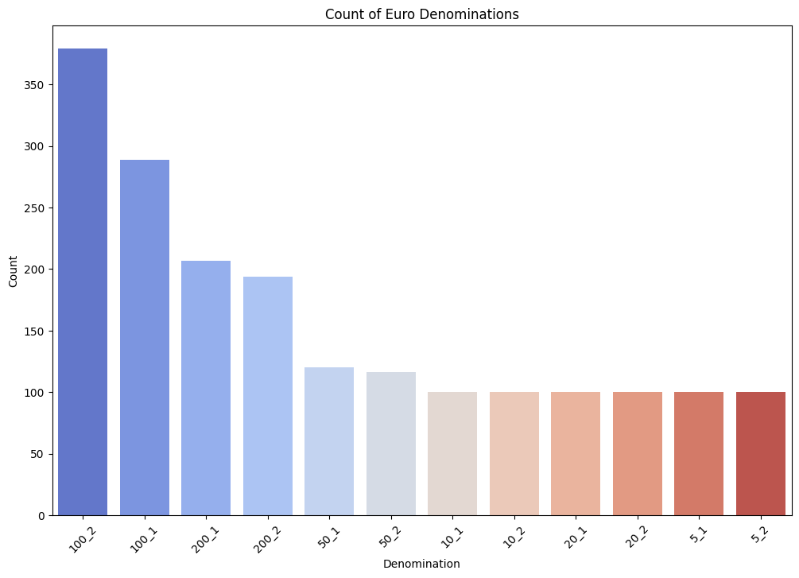

```python
# Count the occurrences of each denomination
denomination_counts = currency_data['Denomination'].value_counts().reset_index()
denomination_counts.columns = ['Denomination', 'Count']

# Create a bar plot
plt.figure(figsize=(12, 8))
sns.barplot(data=denomination_counts, x='Denomination', y='Count', palette='coolwarm',hue='Denomination')
plt.title('Count of Euro Denominations')
plt.xlabel('Denomination')
plt.ylabel('Count')
plt.xticks(rotation=45)  # Rotate labels to make them readable
plt.show()
```

- **Euro Denomination Overview**: The bar chart vividly outlines the frequency of each Euro denomination, offering insights into the dataset's structure.
- **Balanced Data Profile**: Denominations below **100** Euros show a relatively even distribution, promoting balanced training for the model.
- **Emphasis on Higher Values**: Higher denominations such as the **100** and **200** Euro notes are more frequently represented, which might enhance the model's accuracy for these values.

```python
# Load and shuffle the dataset
currency_data = currency_data.sample(frac=1, random_state=23200555).reset_index(drop=True)

# Specify the target column
target_column = 'Denomination'
features = currency_data.drop(currency_data.columns[-2:], axis=1)
labels = currency_data[target_column].astype("category")

# Get input shape and number of classes
input_shape = features.shape[1]
num_classes = labels.unique().shape[0]

# Split the data into training and testing sets with stratification
X_train, X_test, y_train, y_test = train_test_split(
    features, labels, test_size=0.2, random_state=23200555, stratify=labels
)

# One hot encoding y_train and y_test
y_train = pd.get_dummies(y_train)
y_test = pd.get_dummies(y_test)
```

### Model Definition

```python
def create_model(units=128, dropout_rate=0.1):
    model = Sequential([
        Input(shape=(input_shape,)),
        Dense(units, activation='relu'),
        Dropout(dropout_rate),
        Dense(num_classes, activation='softmax')  # Softmax for multi-class classification
    ])
    model.compile(
        optimizer=Adam(learning_rate=1e-3),
        loss='categorical_crossentropy',  # Use categorical cross-entropy for one-hot encoded labels
        metrics=['accuracy', Precision(name='precision'), Recall(name='recall')]
    )
    return model
```

The **denomination neural network classifier** is defined with a straightforward architecture suited for multi-class classification:

1. **Input Layer**: Accepts input with a shape corresponding to the number of features.
2. **Dense Layer**: A fully connected layer with **ReLU** activation. The number of neurons is configurable.
3. **Dropout Layer**: Helps in preventing overfitting by randomly setting a fraction of input units to 0 at each update during training. The rate is adjustable.
4. **Output Layer**: A dense layer with **softmax** activation to output probabilities for each class.

**Compilation**:

- The model is compiled using the Adam optimizer with a learning rate of **0.001**.
- The loss function is categorical crossentropy, which is appropriate for multi-class classification where labels are one-hot encoded.
- **Accuracy**, **precision**, and **recall** are included as metrics to monitor the model's performance during training.

### Fine-Tuning Model Parameters

#### Understanding Hyperparameters

Before diving into the optimization process, let's break down the hyperparameters we are focusing on:

- **Neurons in Hidden Layers**: Determines the capacity of the model to learn complex patterns. More neurons can capture detailed features but may also lead to overfitting.
- **Dropout Rate**: Helps prevent the model from becoming too reliant on any single neuron by randomly dropping units during training. This enhances the model's ability to generalize to new data.

We will systematically tune these parameters to find the best configuration that balances learning depth with the ability to generalize, crucial for the reliable recognition of Euro denominations.

```python
def calculate_f1_score(precision, recall):
    if (precision + recall) == 0:
        return 0  # Avoid division by zero
    return 2 * (precision * recall) / (precision + recall)

# Define batch size
batch_size = 128

# Define the grid of hyperparameters to search
units_options = np.arange(64, 513, 64)
dropout_options = np.arange(0.1, 0.6, 0.1)

# Initialize variables to store the best configuration
best_f1_score = 0
best_units = None
best_dropout = None
best_model = None
results = []

start_time = time.time()

# Stratified K-Fold cross-validation
skf = StratifiedKFold(n_splits=4, shuffle=True, random_state=23200555)

for units in units_options:
  for dropout in dropout_options:
        f1_scores = []
        val_accuracies = []
        val_losses = []

        print(f"Training model with {units} units and {dropout:.2f} dropout rate")
        for train_index, val_index in skf.split(X_train, y_train.idxmax(axis=1)):
            X_train_fold, X_val_fold = X_train.iloc[train_index], X_train.iloc[val_index]
            y_train_fold, y_val_fold = y_train.iloc[train_index], y_train.iloc[val_index]

            # initialize the model with hyperparameters
            model = create_model(units=units, dropout_rate=dropout)
            early_stop_acc = EarlyStopping(monitor="val_accuracy", patience=5, restore_best_weights=True)
            early_stop_loss = EarlyStopping(monitor="val_loss", patience=3, restore_best_weights=True)

            history = model.fit(
                X_train_fold, y_train_fold,
                validation_data=(X_val_fold, y_val_fold),
                epochs=30, batch_size=batch_size, callbacks=[early_stop_acc, early_stop_loss],verbose=0
            )

            val_accuracy = max(history.history['val_accuracy'])
            val_loss = min(history.history['val_loss'])
            # Retrieve and calculate F1 score using specific keys for precision and recall
            precision = history.history['val_precision'][-1]
            recall = history.history['val_recall'][-1]

            f1 = calculate_f1_score(precision, recall)
            val_accuracies.append(val_accuracy)
            val_losses.append(val_loss)
            f1_scores.append(f1)
        # Average validation accuracy and loss over the folds
        avg_val_accuracy = np.mean(val_accuracies)
        avg_val_loss = np.mean(val_losses)
        # Average F1 score across folds
        avg_f1_score = np.mean(f1_scores)
        results.append((units, dropout, avg_val_accuracy, avg_val_loss, avg_f1_score))

        print(f"Validation F1 Score: {avg_f1_score:.4f}")
        print(f"Validation Accuracy: {avg_val_accuracy:.4f}")
        print(f"Validation Loss: {avg_val_loss:.4f}")
        print("-" * 50)
        if avg_f1_score > best_f1_score:
            best_f1_score = avg_f1_score
            best_units = units
            best_dropout = dropout
            best_model = model
duration = time.time() - start_time
print(f"Grid search completed in {duration:.2f} seconds")
print(f"Best model found with {best_units} units and {best_dropout:.2f} dropout rate, F1 Score: {best_f1_score}")
```

```
Training model with 64 units and 0.10 dropout rate
Validation F1 Score: 0.9718
Validation Accuracy: 0.9757
Validation Loss: 0.0939
--------------------------------------------------
Training model with 64 units and 0.20 dropout rate
Validation F1 Score: 0.9737
Validation Accuracy: 0.9757
Validation Loss: 0.0948
--------------------------------------------------
Training model with 64 units and 0.30 dropout rate
Validation F1 Score: 0.9731
Validation Accuracy: 0.9744
Validation Loss: 0.0917
--------------------------------------------------
Training model with 64 units and 0.40 dropout rate
Validation F1 Score: 0.9676
Validation Accuracy: 0.9665
Validation Loss: 0.1156
--------------------------------------------------
Training model with 64 units and 0.50 dropout rate
Validation F1 Score: 0.9693
Validation Accuracy: 0.9711
Validation Loss: 0.1041
--------------------------------------------------
Training model with 128 units and 0.10 dropout rate
Validation F1 Score: 0.9738
Validation Accuracy: 0.9744
Validation Loss: 0.0906
--------------------------------------------------
Training model with 128 units and 0.20 dropout rate
Validation F1 Score: 0.9735
Validation Accuracy: 0.9757
Validation Loss: 0.0817
--------------------------------------------------
Training model with 128 units and 0.30 dropout rate
Validation F1 Score: 0.9755
Validation Accuracy: 0.9803
Validation Loss: 0.0746
--------------------------------------------------
```

[output cut: 147 more lines]

```
Validation Accuracy: 0.9783
Validation Loss: 0.0724
--------------------------------------------------
Training model with 512 units and 0.40 dropout rate
Validation F1 Score: 0.9802
Validation Accuracy: 0.9829
Validation Loss: 0.0674
--------------------------------------------------
Training model with 512 units and 0.50 dropout rate
Validation F1 Score: 0.9798
Validation Accuracy: 0.9823
Validation Loss: 0.0667
--------------------------------------------------
Grid search completed in 525.06 seconds
Best model found with 384 units and 0.50 dropout rate, F1 Score: 0.9801856722129967
```

In the above cell, we employed a methodical approach to determine the optimal model configuration using grid search and Stratified K-Fold cross-validation. Here’s a breakdown of our process:

- **Hyperparameter Range**:
  - **Hidden Layer Neurons**: Configurations ranged from 64 to 512 neurons.
  - **Dropout Rate**: Experimented with rates from 0.1 to 0.5 to mitigate overfitting.
- **Validation Strategy**:
  - Stratified K-Fold cross-validation with four splits was used to enhance the robustness and generalizability of our model.
- **Metric for Model Selection**:
  - The F1-score was pivotal in selecting the best model, balancing precision and recall effectively, which is crucial for handling potentially imbalanced class distributions.

Post completion of grid search, the best model configuration was found to be **384** units in hidden layer with **0.5** dropout rate, achieving an F1 Score of **0.9802**.

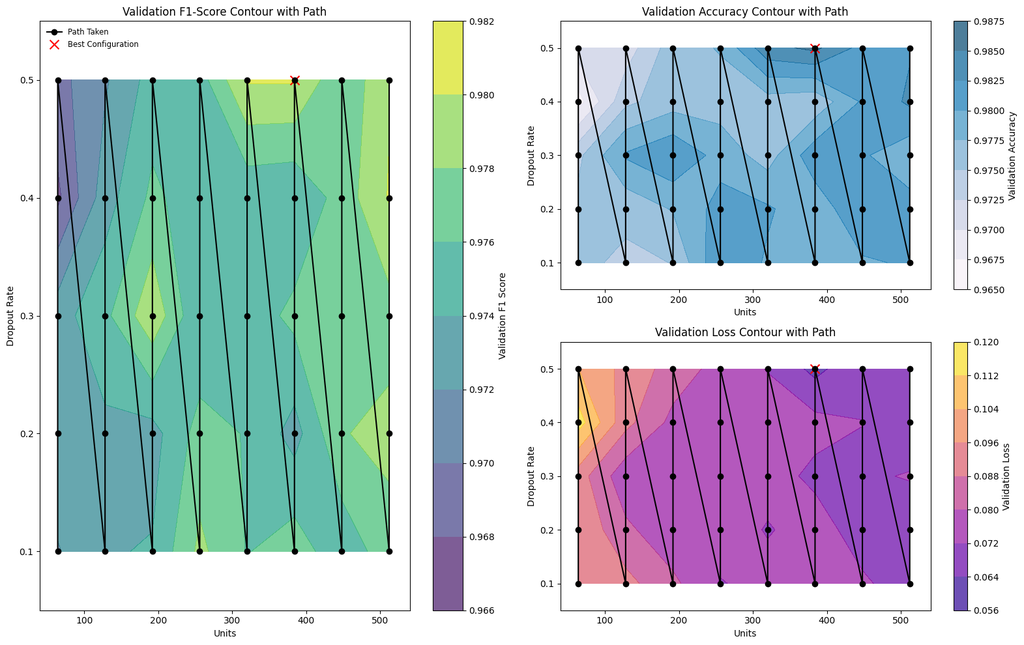

```python
results_df = pd.DataFrame(results, columns=['units', 'dropout', 'val_accuracy', 'val_loss','val_f1_score'])

# Reshape data for contour plotting
units_unique = np.unique(results_df['units'])
dropout_unique = np.unique(results_df['dropout'])
units_grid, dropout_grid = np.meshgrid(units_unique, dropout_unique)
val_f1_score_grid = results_df.pivot(index='dropout', columns='units', values='val_f1_score').values
val_accuracy_grid = results_df.pivot(index='dropout', columns='units', values='val_accuracy').values
val_loss_grid = results_df.pivot(index='dropout', columns='units', values='val_loss').values

plt.figure(figsize=(16,10))
# Plot Contour for  Validation F1-Score/Accuracy/Loss with Path
# Validation F1-Score Plot
ax1 = plt.subplot2grid((2, 2), (0, 0), rowspan=2)
contour_f1 = ax1.contourf(units_grid, dropout_grid, val_f1_score_grid, cmap='viridis', alpha=0.7)
plt.colorbar(contour_f1, ax=ax1, label='Validation F1 Score')
ax1.plot(results_df['units'], results_df['dropout'], 'ko-', label='Path Taken')
ax1.scatter([best_units], [best_dropout], color='red', marker='x', s=100, label='Best Configuration')
ax1.set_title('Validation F1-Score Contour with Path')
ax1.set_xlabel('Units')
ax1.set_ylabel('Dropout Rate')
ax1.set_xlim(40, 540)
ax1.set_ylim(0.05, 0.55)
ax1.legend(loc='upper left', fontsize='small', frameon=False)

# Validation Accuracy Plot
ax2 = plt.subplot2grid((2, 2), (0, 1))
contour_acc = ax2.contourf(units_grid, dropout_grid, val_accuracy_grid, cmap='PuBu', alpha=0.7)
plt.colorbar(contour_acc, ax=ax2, label='Validation Accuracy')
ax2.plot(results_df['units'], results_df['dropout'], 'ko-', label='Path Taken')
ax2.scatter([best_units], [best_dropout], color='red', marker='x', s=100, label='Best Configuration')
ax2.set_title('Validation Accuracy Contour with Path')
ax2.set_xlabel('Units')
ax2.set_ylabel('Dropout Rate')
ax2.set_xlim(40, 540)
ax2.set_ylim(0.05, 0.55)

# Validation Loss Plot
ax3 = plt.subplot2grid((2, 2), (1, 1))
contour_loss = ax3.contourf(units_grid, dropout_grid, val_loss_grid, cmap='plasma', alpha=0.7)
plt.colorbar(contour_loss, ax=ax3, label='Validation Loss')
ax3.plot(results_df['units'], results_df['dropout'], 'ko-', label='Path Taken')
ax3.scatter([best_units], [best_dropout], color='red', marker='x', s=100, label='Best Configuration')
ax3.set_title('Validation Loss Contour with Path')
ax3.set_xlabel('Units')
ax3.set_ylabel('Dropout Rate')
ax3.set_xlim(40, 540)
ax3.set_ylim(0.05, 0.55)


plt.tight_layout()
plt.show()
```

### Final Model Training

Now, we will train the final model using the best hyperparameters obtained from our extensive testing. Here’s what we're doing:

```python
# Create the model with the best hyperparameters
final_model = create_model(units=best_units, dropout_rate=best_dropout)

# Set up callbacks for early stopping
checkpoint = ModelCheckpoint(
    filepath="trained_models/best_model.h5",
    monitor="val_accuracy",
    save_best_only=True,
    verbose=1
)

early_stop_acc = EarlyStopping(monitor="val_accuracy", patience=5, restore_best_weights=True, verbose=1)
early_stop_loss = EarlyStopping(monitor="val_loss", patience=5, restore_best_weights=True, verbose=1)

# Train the final model on the full training set
start_time = time.time()

history = final_model.fit(
    X_train, y_train,
    validation_data=(X_test, y_test),
    epochs=30,  # You can adjust the number of epochs as needed
    batch_size=batch_size,
    callbacks=[checkpoint,early_stop_loss,early_stop_acc],
    verbose=1
)

duration = time.time() - start_time

print(f"Final model training completed in {duration:.2f} seconds")
```

```
Epoch 1: val_accuracy improved from -inf to 0.94488, saving model to trained_models/best_model.h5
Epoch 2: val_accuracy improved from 0.94488 to 0.97375, saving model to trained_models/best_model.h5
Epoch 3: val_accuracy improved from 0.97375 to 0.97638, saving model to trained_models/best_model.h5
Epoch 4: val_accuracy did not improve from 0.97638
Epoch 5: val_accuracy improved from 0.97638 to 0.97900, saving model to trained_models/best_model.h5
Epoch 6: val_accuracy improved from 0.97900 to 0.98425, saving model to trained_models/best_model.h5
Epoch 7: val_accuracy did not improve from 0.98425
Epoch 8: val_accuracy improved from 0.98425 to 0.98950, saving model to trained_models/best_model.h5
Epoch 9: val_accuracy did not improve from 0.98950
Epoch 10: val_accuracy did not improve from 0.98950
Epoch 11: val_accuracy did not improve from 0.98950
Epoch 12: val_accuracy did not improve from 0.98950
Epoch 13: val_accuracy improved from 0.98950 to 0.99213, saving model to trained_models/best_model.h5
Epoch 14: val_accuracy improved from 0.99213 to 0.99475, saving model to trained_models/best_model.h5
Epoch 15: val_accuracy did not improve from 0.99475
Epoch 16: val_accuracy did not improve from 0.99475
Epoch 17: val_accuracy did not improve from 0.99475
Epoch 18: val_accuracy did not improve from 0.99475
Epoch 19: val_accuracy did not improve from 0.99475
Restoring model weights from the end of the best epoch: 14.
Epoch 19: early stopping
Final model training completed in 4.15 seconds
```

Now, let's visually assess the performance of our final model across epochs.

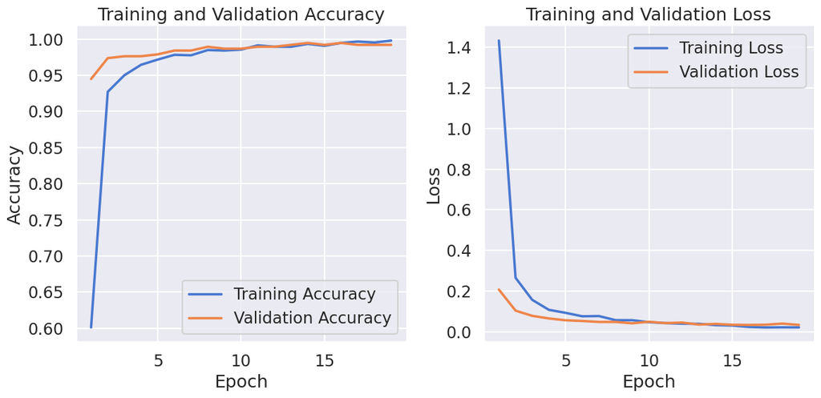

```python
# Set the style of Seaborn to 'dark'
sns.set(style="darkgrid", context='talk', palette='muted')

# Create a figure with a specified size
plt.figure(figsize=(12, 6))

# Convert the history data to a DataFrame for easier plotting
history_df = pd.DataFrame(history.history)
history_df['Epoch'] = history_df.index + 1

# Plot Training and Validation Accuracy
plt.subplot(1, 2, 1)
sns.lineplot(data=history_df, x='Epoch', y='accuracy', label='Training Accuracy', linewidth=2.5)
sns.lineplot(data=history_df, x='Epoch', y='val_accuracy', label='Validation Accuracy', linewidth=2.5)
plt.title('Training and Validation Accuracy')
plt.xlabel('Epoch')
plt.ylabel('Accuracy')
plt.legend()

# Plot Training and Validation Loss
plt.subplot(1, 2, 2)
sns.lineplot(data=history_df, x='Epoch', y='loss', label='Training Loss', linewidth=2.5)
sns.lineplot(data=history_df, x='Epoch', y='val_loss', label='Validation Loss', linewidth=2.5)
plt.title('Training and Validation Loss')
plt.xlabel('Epoch')
plt.ylabel('Loss')
plt.legend()

# Remove top and right borders
sns.despine()

plt.tight_layout()
plt.show()
```

- **Accuracy Trends**: The accuracy plot indicates a swift increase in both training and validation accuracy during the initial epochs, demonstrating that the model quickly learns to classify the denominations effectively. The convergence of training and validation accuracy suggests a good generalization to unseen data.
- **Loss Trends**: The loss plot shows a steep decrease in both training and validation loss, stabilizing after a few epochs. This trend confirms that the model's predictions are becoming increasingly accurate as training progresses, and it effectively minimizes errors over time.

### Model Evaluation

In this section, we evaluate the **out-of-sample performance** of our trained model. By making predictions on the test set and comparing them to the true labels, we can measure the accuracy of our model across different Euro denominations.

```python
# Make predictions using final_model on test_set
predictions = final_model.predict(X_test)
predicted_labels = np.argmax(predictions, axis=1)

# Assuming y_test is also in one-hot encoded format
true_labels = np.argmax(y_test, axis=1)

# Generate classification report
report = classification_report(true_labels, predicted_labels, target_names=y_test.columns.tolist())

print("Classification Report:")
print(report)
```

```
Classification Report:
              precision    recall  f1-score   support

       100_1       1.00      1.00      1.00        58
       100_2       1.00      1.00      1.00        76
        10_1       1.00      1.00      1.00        20
        10_2       1.00      1.00      1.00        20
       200_1       1.00      1.00      1.00        41
       200_2       1.00      1.00      1.00        39
        20_1       1.00      1.00      1.00        20
        20_2       1.00      1.00      1.00        20
        50_1       0.92      1.00      0.96        24
        50_2       1.00      0.91      0.95        23
         5_1       1.00      1.00      1.00        20
         5_2       1.00      1.00      1.00        20

    accuracy                           0.99       381
   macro avg       0.99      0.99      0.99       381
weighted avg       1.00      0.99      0.99       381
```

From the classification report shown above, it's evident that our model performs exceptionally well across various Euro denominations:

- **Precision and Recall:** The model consistently achieves a precision and recall of 1.00 for most classes, indicating a high degree of accuracy in correctly identifying the denominations.
- **F1-Score:** The F1-scores, which balance precision and recall, are near perfect for almost all denominations, highlighting the model's efficiency in accurate classification.
- **Support:** The support values indicate the number of samples for each denomination class used in testing, providing insight into the dataset's distribution and the model's exposure during training.
- **Overall Accuracy:** Achieving an overall accuracy of 0.99, the model demonstrates its capability to generalize well to new, unseen data, making it highly reliable for practical applications in currency denomination recognition.

We will next examine the confusion matrix to better understand the specific performance challenges with the **50_1** and **50_2** classes, where the precision and recall are not nearly perfect, to identify possible areas for model improvement.

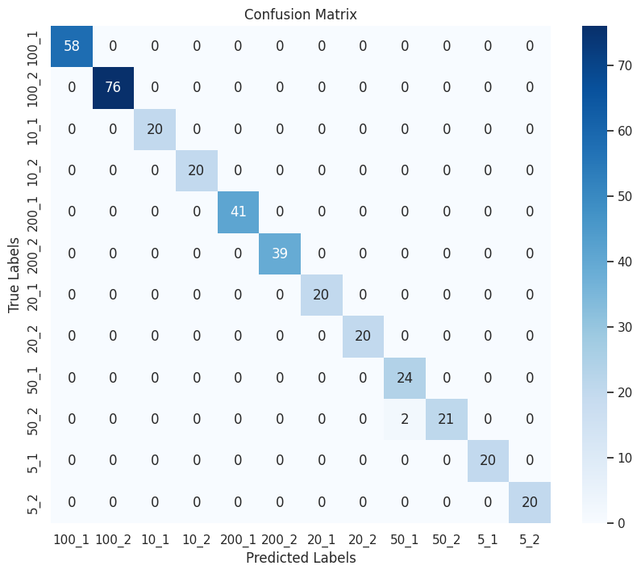

```python
# Generate the confusion matrix
cm = confusion_matrix(true_labels, predicted_labels)

# Plotting the confusion matrix
plt.figure(figsize=(10, 8))
sns.set(style="whitegrid", palette="muted")
ax = sns.heatmap(cm, annot=True, fmt='d', cmap='Blues', xticklabels=list(y_train.columns), yticklabels=list(y_train.columns))
plt.title('Confusion Matrix')
plt.xlabel('Predicted Labels')
plt.ylabel('True Labels')
plt.show()
```

According to the confusion matrix, the model exhibits some difficulty in distinguishing between the front and back faces of the 50 Euro denomination, with a few instances where one face is mistaken for the other. Despite this, the model successfully identifies the denomination itself in all cases. This suggests that while the model may need enhancements in recognizing note orientations, its proficiency in determining the correct denomination is effectively maintained, offering practical assistance in currency recognition for visually impaired users.